# STEP1:READING AND UNDERSTANDING THE DATA

```python
import numpy as np
import pandas as pd
import seaborn as sns
import matplotlib.pyplot as plt
from sklearn.model_selection import train_test_split
from sklearn.preprocessing import MinMaxScaler
from sklearn.feature_selection import RFE
from sklearn.linear_model import LinearRegression
from statsmodels.stats.outliers_influence import variance_inflation_factor
import statsmodels.api as sm
from sklearn.metrics import r2_score
import warnings
warnings.filterwarnings('ignore')
```

```python
day = pd.read_csv('day (1).csv')
day.head()
```

|  | instant | dteday | season | yr | mnth | holiday | weekday | workingday | weathersit | temp | atemp | hum | windspeed | casual | registered | cnt |
| --- | --- | --- | --- | --- | --- | --- | --- | --- | --- | --- | --- | --- | --- | --- | --- | --- |
| 0 | 1 | 01-01-2018 | 1 | 0 | 1 | 0 | 1 | 1 | 2 | 14.110847 | 18.18125 | 80.5833 | 10.749882 | 331 | 654 | 985 |
| 1 | 2 | 02-01-2018 | 1 | 0 | 1 | 0 | 2 | 1 | 2 | 14.902598 | 17.68695 | 69.6087 | 16.652113 | 131 | 670 | 801 |
| 2 | 3 | 03-01-2018 | 1 | 0 | 1 | 0 | 3 | 1 | 1 | 8.050924 | 9.47025 | 43.7273 | 16.636703 | 120 | 1229 | 1349 |
| 3 | 4 | 04-01-2018 | 1 | 0 | 1 | 0 | 4 | 1 | 1 | 8.200000 | 10.60610 | 59.0435 | 10.739832 | 108 | 1454 | 1562 |
| 4 | 5 | 05-01-2018 | 1 | 0 | 1 | 0 | 5 | 1 | 1 | 9.305237 | 11.46350 | 43.6957 | 12.522300 | 82 | 1518 | 1600 |

```python
day.info()
```

```
<class 'pandas.core.frame.DataFrame'>
RangeIndex: 730 entries, 0 to 729
Data columns (total 16 columns):
 #   Column      Non-Null Count  Dtype
---  ------      --------------  -----
 0   instant     730 non-null    int64
 1   dteday      730 non-null    object
 2   season      730 non-null    int64
 3   yr          730 non-null    int64
 4   mnth        730 non-null    int64
 5   holiday     730 non-null    int64
 6   weekday     730 non-null    int64
 7   workingday  730 non-null    int64
 8   weathersit  730 non-null    int64
 9   temp        730 non-null    float64
 10  atemp       730 non-null    float64
 11  hum         730 non-null    float64
 12  windspeed   730 non-null    float64
 13  casual      730 non-null    int64
 14  registered  730 non-null    int64
 15  cnt         730 non-null    int64
dtypes: float64(4), int64(11), object(1)
memory usage: 91.4+ KB
```

```python
day.describe()
```

|  | instant | season | yr | mnth | holiday | weekday | workingday | weathersit | temp | atemp | hum | windspeed | casual | registered | cnt |
| --- | --- | --- | --- | --- | --- | --- | --- | --- | --- | --- | --- | --- | --- | --- | --- |
| count | 730.000000 | 730.000000 | 730.000000 | 730.000000 | 730.000000 | 730.000000 | 730.000000 | 730.000000 | 730.000000 | 730.000000 | 730.000000 | 730.000000 | 730.000000 | 730.000000 | 730.000000 |
| mean | 365.500000 | 2.498630 | 0.500000 | 6.526027 | 0.028767 | 2.995890 | 0.690411 | 1.394521 | 20.319259 | 23.726322 | 62.765175 | 12.763620 | 849.249315 | 3658.757534 | 4508.006849 |
| std | 210.877136 | 1.110184 | 0.500343 | 3.450215 | 0.167266 | 2.000339 | 0.462641 | 0.544807 | 7.506729 | 8.150308 | 14.237589 | 5.195841 | 686.479875 | 1559.758728 | 1936.011647 |
| min | 1.000000 | 1.000000 | 0.000000 | 1.000000 | 0.000000 | 0.000000 | 0.000000 | 1.000000 | 2.424346 | 3.953480 | 0.000000 | 1.500244 | 2.000000 | 20.000000 | 22.000000 |
| 25% | 183.250000 | 2.000000 | 0.000000 | 4.000000 | 0.000000 | 1.000000 | 0.000000 | 1.000000 | 13.811885 | 16.889713 | 52.000000 | 9.041650 | 316.250000 | 2502.250000 | 3169.750000 |
| 50% | 365.500000 | 3.000000 | 0.500000 | 7.000000 | 0.000000 | 3.000000 | 1.000000 | 1.000000 | 20.465826 | 24.368225 | 62.625000 | 12.125325 | 717.000000 | 3664.500000 | 4548.500000 |
| 75% | 547.750000 | 3.000000 | 1.000000 | 10.000000 | 0.000000 | 5.000000 | 1.000000 | 2.000000 | 26.880615 | 30.445775 | 72.989575 | 15.625589 | 1096.500000 | 4783.250000 | 5966.000000 |
| max | 730.000000 | 4.000000 | 1.000000 | 12.000000 | 1.000000 | 6.000000 | 1.000000 | 3.000000 | 35.328347 | 42.044800 | 97.250000 | 34.000021 | 3410.000000 | 6946.000000 | 8714.000000 |

```python
day.isnull().sum()
```

```
instant       0
dteday        0
season        0
yr            0
mnth          0
holiday       0
weekday       0
workingday    0
weathersit    0
temp          0
atemp         0
hum           0
windspeed     0
casual        0
registered    0
cnt           0
dtype: int64
```

### DROPPING UNWANTED COLUMNS

Let us drop instant bcoz it is just the index for each row,dteday bcoz it only shows date which can be observed with the help of yr and mnth columns,casual and registered column bcoz combination of these two shows cnt column

```python
#dropping columns
day.drop(['instant','dteday','casual','registered'],axis = 1,inplace = True)
```

```python
#renaming column for better readability'
day.rename(columns={'yr':'year','mnth':'month','hum':'humidity'},inplace = True)
```

### Converting numerical value into specified categorical value

```python
#Mapping numerical values of season to specified labels.
day.season = day.season.map({1:'Spring',2:'Summer',3:'Fall',4:'Winter'})
```

```python
#Mapping numerical values of month to specified labels.
day.month = day.month.map({1:'JAN',2:'Feb',3:'MAR',4:'APR',5:'MAY',6:'JUN',7:'JUL',8:'AUG',9:'SEPT',10:'OCT',11:'NOV',12:'DEC'})
```

```python
#Mapping numerical values of weekday to specified labels.
day.weekday = day.weekday.map({0:'SUN',1:"MON",2:'TUE',4:"WED",5:'THUR',6:'FRI',7:"SAT"})
```

```python
#Mapping numerical values of weathersit to specified labels.
day.weathersit= day.weathersit.map({1:"CLEAR",2:"MIST",3:"LIGHT_SNOW_RAIN",4:"HEAVY_SNOW_RAIN"})
```

```python
day.head()
```

|  | season | year | month | holiday | weekday | workingday | weathersit | temp | atemp | humidity | windspeed | cnt |
| --- | --- | --- | --- | --- | --- | --- | --- | --- | --- | --- | --- | --- |
| 0 | Spring | 0 | JAN | 0 | MON | 1 | MIST | 14.110847 | 18.18125 | 80.5833 | 10.749882 | 985 |
| 1 | Spring | 0 | JAN | 0 | TUE | 1 | MIST | 14.902598 | 17.68695 | 69.6087 | 16.652113 | 801 |
| 2 | Spring | 0 | JAN | 0 | NaN | 1 | CLEAR | 8.050924 | 9.47025 | 43.7273 | 16.636703 | 1349 |
| 3 | Spring | 0 | JAN | 0 | WED | 1 | CLEAR | 8.200000 | 10.60610 | 59.0435 | 10.739832 | 1562 |
| 4 | Spring | 0 | JAN | 0 | THUR | 1 | CLEAR | 9.305237 | 11.46350 | 43.6957 | 12.522300 | 1600 |

# STEP2:VISUALIZING THE DATA

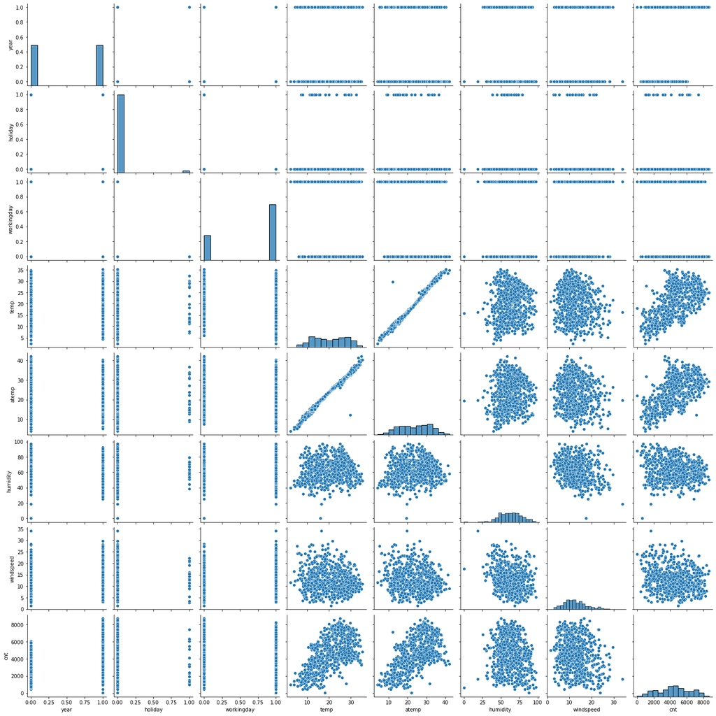

```python
#visualizing the numerical variales
sns.pairplot(day)
plt.show()
```

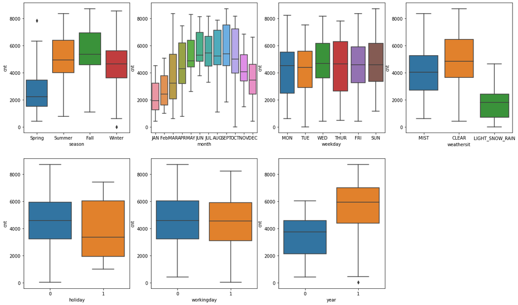

```python
#Analysing/visualizing the categorical columns
# to see how predictor variable stands against the target variable

plt.figure(figsize=(20, 12))
plt.subplot(2,4,1)
sns.boxplot(x = 'season', y = 'cnt', data = day)
plt.subplot(2,4,2)
sns.boxplot(x = 'month', y = 'cnt', data = day)
plt.subplot(2,4,3)
sns.boxplot(x = 'weekday', y = 'cnt', data = day)
plt.subplot(2,4,4)
sns.boxplot(x = 'weathersit', y = 'cnt', data = day)
plt.subplot(2,4,5)
sns.boxplot(x = 'holiday', y = 'cnt', data = day)
plt.subplot(2,4,6)
sns.boxplot(x = 'workingday', y = 'cnt', data = day)
plt.subplot(2,4,7)
sns.boxplot(x = 'year', y = 'cnt', data = day)
plt.show()
```

### From above plots we can draw many insights such as:

Season:Fall has highest demand for rental bikes.Every month the demand for rental bike is increasing till June.September has the highest number of demands than it is decreasing.During weekdays and workingdays demand don't have that much of variation.Clear weathersit has highest demand.When there is holiday,demand has decreased.I cans see that demand for next year has grown.

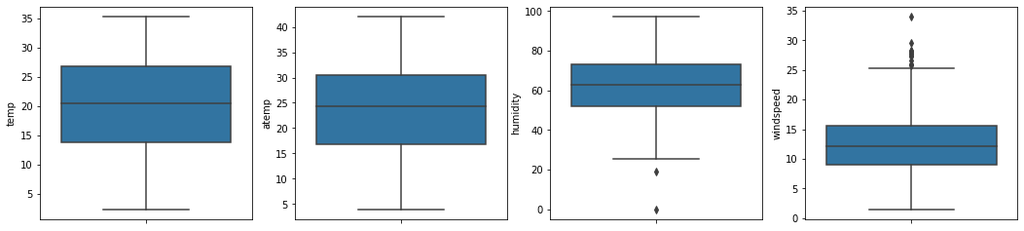

```python
#DRAW BOX PLOTS FOR INDEPENDENT VARIABLES WITH CONTINUOUSN VALUES
cols = ['temp','atemp','humidity','windspeed']
plt.figure(figsize=(18,4))

i=1
for col in cols:
    plt.subplot(1,4,i)
    sns.boxplot(y=col,data=day)
    i+=1
```

##### From above,we can say that there are no outliers to be handled.So we can proceed with this values.

### VISUALISING NUMERICAL VARIABLES

#### Let's make a pairplot of all the numeric variables

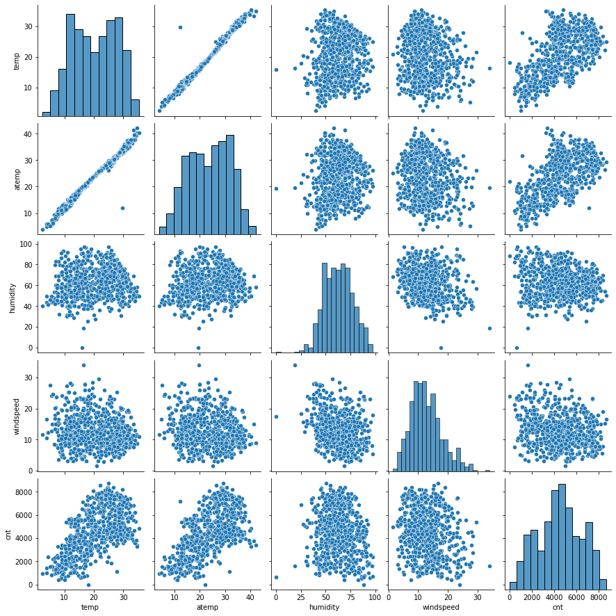

```python
sns.pairplot(data=day,vars=['temp','atemp','humidity','windspeed','cnt'])
plt.show()
```

##### From above,we can say that temp and atemp has highest correlation with the largest variable 'cnt'.And it is also observed that temp and atemp are highly correalted with each other.

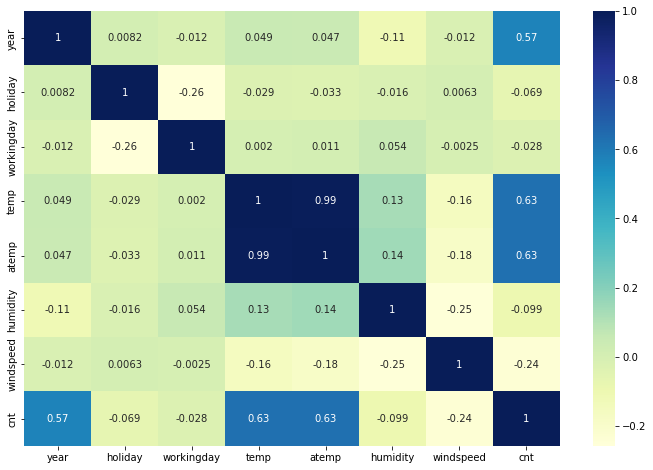

```python
#Let's check the correaltion coefficients to see which variables are highly correlated

plt.figure(figsize = (12,8))
sns.heatmap(day.corr(),annot = True,cmap = 'YlGnBu')
plt.show()
```

##### From above,we can say that temp and atemp are highly correlated means both the variables together cannot be used in model because it will lead to multicollinearity.So from VIF and p-value we will consider which variable to take.

```python
day.head()
```

|  | season | year | month | holiday | weekday | workingday | weathersit | temp | atemp | humidity | windspeed | cnt |
| --- | --- | --- | --- | --- | --- | --- | --- | --- | --- | --- | --- | --- |
| 0 | Spring | 0 | JAN | 0 | MON | 1 | MIST | 14.110847 | 18.18125 | 80.5833 | 10.749882 | 985 |
| 1 | Spring | 0 | JAN | 0 | TUE | 1 | MIST | 14.902598 | 17.68695 | 69.6087 | 16.652113 | 801 |
| 2 | Spring | 0 | JAN | 0 | NaN | 1 | CLEAR | 8.050924 | 9.47025 | 43.7273 | 16.636703 | 1349 |
| 3 | Spring | 0 | JAN | 0 | WED | 1 | CLEAR | 8.200000 | 10.60610 | 59.0435 | 10.739832 | 1562 |
| 4 | Spring | 0 | JAN | 0 | THUR | 1 | CLEAR | 9.305237 | 11.46350 | 43.6957 | 12.522300 | 1600 |

## DATA PREPARATION

### DUMMY VARIABLES

```python
day.head()
```

|  | season | year | month | holiday | weekday | workingday | weathersit | temp | atemp | humidity | windspeed | cnt |
| --- | --- | --- | --- | --- | --- | --- | --- | --- | --- | --- | --- | --- |
| 0 | Spring | 0 | JAN | 0 | MON | 1 | MIST | 14.110847 | 18.18125 | 80.5833 | 10.749882 | 985 |
| 1 | Spring | 0 | JAN | 0 | TUE | 1 | MIST | 14.902598 | 17.68695 | 69.6087 | 16.652113 | 801 |
| 2 | Spring | 0 | JAN | 0 | NaN | 1 | CLEAR | 8.050924 | 9.47025 | 43.7273 | 16.636703 | 1349 |
| 3 | Spring | 0 | JAN | 0 | WED | 1 | CLEAR | 8.200000 | 10.60610 | 59.0435 | 10.739832 | 1562 |
| 4 | Spring | 0 | JAN | 0 | THUR | 1 | CLEAR | 9.305237 | 11.46350 | 43.6957 | 12.522300 | 1600 |

```python
#creating dummy values for all categorical varaibles

data=pd.get_dummies(data=day,columns=['season','month','weekday','weathersit'],drop_first=True)
```

```python
data.head()
```

|  | year | holiday | workingday | temp | atemp | humidity | windspeed | cnt | season_Spring | season_Summer | ... | month_NOV | month_OCT | month_SEPT | weekday_MON | weekday_SUN | weekday_THUR | weekday_TUE | weekday_WED | weathersit_LIGHT_SNOW_RAIN | weathersit_MIST |
| --- | --- | --- | --- | --- | --- | --- | --- | --- | --- | --- | --- | --- | --- | --- | --- | --- | --- | --- | --- | --- | --- |
| 0 | 0 | 0 | 1 | 14.110847 | 18.18125 | 80.5833 | 10.749882 | 985 | 1 | 0 | ... | 0 | 0 | 0 | 1 | 0 | 0 | 0 | 0 | 0 | 1 |
| 1 | 0 | 0 | 1 | 14.902598 | 17.68695 | 69.6087 | 16.652113 | 801 | 1 | 0 | ... | 0 | 0 | 0 | 0 | 0 | 0 | 1 | 0 | 0 | 1 |
| 2 | 0 | 0 | 1 | 8.050924 | 9.47025 | 43.7273 | 16.636703 | 1349 | 1 | 0 | ... | 0 | 0 | 0 | 0 | 0 | 0 | 0 | 0 | 0 | 0 |
| 3 | 0 | 0 | 1 | 8.200000 | 10.60610 | 59.0435 | 10.739832 | 1562 | 1 | 0 | ... | 0 | 0 | 0 | 0 | 0 | 0 | 0 | 1 | 0 | 0 |
| 4 | 0 | 0 | 1 | 9.305237 | 11.46350 | 43.6957 | 12.522300 | 1600 | 1 | 0 | ... | 0 | 0 | 0 | 0 | 0 | 1 | 0 | 0 | 0 | 0 |

5 rows × 29 columns

```python
data.columns
```

```
Index(['year', 'holiday', 'workingday', 'temp', 'atemp', 'humidity',
       'windspeed', 'cnt', 'season_Spring', 'season_Summer', 'season_Winter',
       'month_AUG', 'month_DEC', 'month_Feb', 'month_JAN', 'month_JUL',
       'month_JUN', 'month_MAR', 'month_MAY', 'month_NOV', 'month_OCT',
       'month_SEPT', 'weekday_MON', 'weekday_SUN', 'weekday_THUR',
       'weekday_TUE', 'weekday_WED', 'weathersit_LIGHT_SNOW_RAIN',
       'weathersit_MIST'],
      dtype='object')
```

# STEP:3 PREPARING THE DATA FOR MODELLING

### Splitting the Data into Training and Testing

```python
#splitting the dataframe into train and test
np.random.seed(0)
```

```python
df_train,df_test=train_test_split(data,train_size =0.7,test_size= 0.3,random_state=100)
```

```python
#checking the shape of train dataset
df_train.shape
```

```
(510, 29)
```

```python
#checking the shape of test dataset
df_test.shape
```

```
(219, 29)
```

### RESCALING THE FEATURES

```python
#using minmaxscaler  to rescale the features
scaler = MinMaxScaler()
```

```python
#verifying the head of dataset before scaling
df_train.head()
```

|  | year | holiday | workingday | temp | atemp | humidity | windspeed | cnt | season_Spring | season_Summer | ... | month_NOV | month_OCT | month_SEPT | weekday_MON | weekday_SUN | weekday_THUR | weekday_TUE | weekday_WED | weathersit_LIGHT_SNOW_RAIN | weathersit_MIST |
| --- | --- | --- | --- | --- | --- | --- | --- | --- | --- | --- | --- | --- | --- | --- | --- | --- | --- | --- | --- | --- | --- |
| 653 | 1 | 0 | 1 | 19.201653 | 23.0423 | 55.8333 | 12.208807 | 7534 | 0 | 0 | ... | 0 | 1 | 0 | 0 | 0 | 0 | 0 | 0 | 0 | 0 |
| 576 | 1 | 0 | 1 | 29.246653 | 33.1448 | 70.4167 | 11.083475 | 7216 | 0 | 0 | ... | 0 | 0 | 0 | 0 | 0 | 0 | 0 | 0 | 0 | 0 |
| 426 | 1 | 0 | 0 | 16.980847 | 20.6746 | 62.1250 | 10.792293 | 4066 | 1 | 0 | ... | 0 | 0 | 0 | 0 | 1 | 0 | 0 | 0 | 0 | 1 |
| 728 | 1 | 0 | 1 | 10.489153 | 11.5850 | 48.3333 | 23.500518 | 1796 | 1 | 0 | ... | 0 | 0 | 0 | 1 | 0 | 0 | 0 | 0 | 0 | 0 |
| 482 | 1 | 0 | 0 | 15.443347 | 18.8752 | 48.9583 | 8.708325 | 4220 | 0 | 1 | ... | 0 | 0 | 0 | 0 | 1 | 0 | 0 | 0 | 0 | 1 |

5 rows × 29 columns

```python
#Applying scaler() to all the columns except the 'yes-no' and 'dummy' variables
num_vars = ['temp','atemp','humidity','windspeed','cnt']
df_train[num_vars] = scaler.fit_transform(df_train[num_vars])
df_train.head()
```

|  | year | holiday | workingday | temp | atemp | humidity | windspeed | cnt | season_Spring | season_Summer | ... | month_NOV | month_OCT | month_SEPT | weekday_MON | weekday_SUN | weekday_THUR | weekday_TUE | weekday_WED | weathersit_LIGHT_SNOW_RAIN | weathersit_MIST |
| --- | --- | --- | --- | --- | --- | --- | --- | --- | --- | --- | --- | --- | --- | --- | --- | --- | --- | --- | --- | --- | --- |
| 653 | 1 | 0 | 1 | 0.509887 | 0.501133 | 0.575354 | 0.300794 | 0.864243 | 0 | 0 | ... | 0 | 1 | 0 | 0 | 0 | 0 | 0 | 0 | 0 | 0 |
| 576 | 1 | 0 | 1 | 0.815169 | 0.766351 | 0.725633 | 0.264686 | 0.827658 | 0 | 0 | ... | 0 | 0 | 0 | 0 | 0 | 0 | 0 | 0 | 0 | 0 |
| 426 | 1 | 0 | 0 | 0.442393 | 0.438975 | 0.640189 | 0.255342 | 0.465255 | 1 | 0 | ... | 0 | 0 | 0 | 0 | 1 | 0 | 0 | 0 | 0 | 1 |
| 728 | 1 | 0 | 1 | 0.245101 | 0.200348 | 0.498067 | 0.663106 | 0.204096 | 1 | 0 | ... | 0 | 0 | 0 | 1 | 0 | 0 | 0 | 0 | 0 | 0 |
| 482 | 1 | 0 | 0 | 0.395666 | 0.391735 | 0.504508 | 0.188475 | 0.482973 | 0 | 1 | ... | 0 | 0 | 0 | 0 | 1 | 0 | 0 | 0 | 0 | 1 |

5 rows × 29 columns

```python
df_train.describe()
```

|  | year | holiday | workingday | temp | atemp | humidity | windspeed | cnt | season_Spring | season_Summer | ... | month_NOV | month_OCT | month_SEPT | weekday_MON | weekday_SUN | weekday_THUR | weekday_TUE | weekday_WED | weathersit_LIGHT_SNOW_RAIN | weathersit_MIST |
| --- | --- | --- | --- | --- | --- | --- | --- | --- | --- | --- | --- | --- | --- | --- | --- | --- | --- | --- | --- | --- | --- |
| count | 510.000000 | 510.000000 | 510.000000 | 510.000000 | 510.000000 | 510.000000 | 510.000000 | 510.000000 | 510.000000 | 510.000000 | ... | 510.000000 | 510.000000 | 510.000000 | 510.000000 | 510.000000 | 510.000000 | 510.000000 | 510.000000 | 510.000000 | 510.000000 |
| mean | 0.507843 | 0.025490 | 0.711765 | 0.537262 | 0.512989 | 0.650369 | 0.320768 | 0.513620 | 0.243137 | 0.245098 | ... | 0.086275 | 0.086275 | 0.080392 | 0.154902 | 0.137255 | 0.147059 | 0.152941 | 0.143137 | 0.029412 | 0.343137 |
| std | 0.500429 | 0.157763 | 0.453386 | 0.225844 | 0.212385 | 0.145882 | 0.169797 | 0.224593 | 0.429398 | 0.430568 | ... | 0.281045 | 0.281045 | 0.272166 | 0.362166 | 0.344454 | 0.354512 | 0.360284 | 0.350557 | 0.169124 | 0.475223 |
| min | 0.000000 | 0.000000 | 0.000000 | 0.000000 | 0.000000 | 0.000000 | 0.000000 | 0.000000 | 0.000000 | 0.000000 | ... | 0.000000 | 0.000000 | 0.000000 | 0.000000 | 0.000000 | 0.000000 | 0.000000 | 0.000000 | 0.000000 | 0.000000 |
| 25% | 0.000000 | 0.000000 | 0.000000 | 0.339853 | 0.332086 | 0.538643 | 0.199179 | 0.356420 | 0.000000 | 0.000000 | ... | 0.000000 | 0.000000 | 0.000000 | 0.000000 | 0.000000 | 0.000000 | 0.000000 | 0.000000 | 0.000000 | 0.000000 |
| 50% | 1.000000 | 0.000000 | 1.000000 | 0.540519 | 0.526811 | 0.653714 | 0.296763 | 0.518638 | 0.000000 | 0.000000 | ... | 0.000000 | 0.000000 | 0.000000 | 0.000000 | 0.000000 | 0.000000 | 0.000000 | 0.000000 | 0.000000 | 0.000000 |
| 75% | 1.000000 | 0.000000 | 1.000000 | 0.735215 | 0.688457 | 0.754830 | 0.414447 | 0.684710 | 0.000000 | 0.000000 | ... | 0.000000 | 0.000000 | 0.000000 | 0.000000 | 0.000000 | 0.000000 | 0.000000 | 0.000000 | 0.000000 | 1.000000 |
| max | 1.000000 | 1.000000 | 1.000000 | 1.000000 | 1.000000 | 1.000000 | 1.000000 | 1.000000 | 1.000000 | 1.000000 | ... | 1.000000 | 1.000000 | 1.000000 | 1.000000 | 1.000000 | 1.000000 | 1.000000 | 1.000000 | 1.000000 | 1.000000 |

8 rows × 29 columns

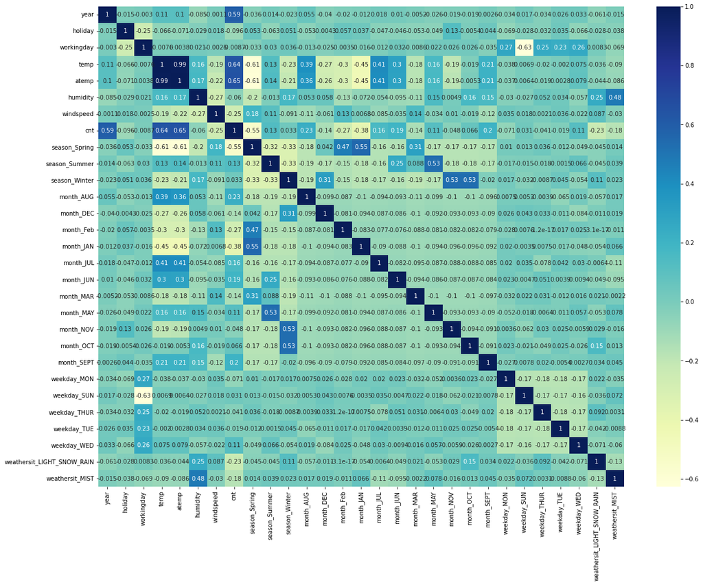

```python
#Let's check the correlation coefficients to see which variables are highly correlated
plt.figure(figsize = (20,15))
sns.heatmap(df_train.corr(),annot=True,cmap='YlGnBu')
plt.show()
```

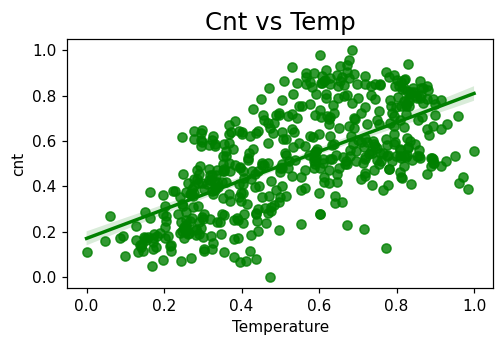

```python
plt.figure(figsize=(5,3),dpi=110)
plt.title("Cnt vs Temp",fontsize=16)
sns.regplot(data=df_train,y='cnt',x='temp',color='green')
plt.xlabel("Temperature")
plt.show()
```

#### From above visualization, we can say that cnt and temp are having positive correlation

```python
y_train = df_train.pop('cnt')
X_train=df_train
```

```python
#RFE - RECURSIVE FEATURE ELMINATION
lm = LinearRegression()
lm.fit(X_train,y_train)

#RUNNING RFE
rfe = RFE(estimator = lm,n_features_to_select=15,step=15)
rfe = rfe.fit(X_train,y_train)
```

```python
#List of variables selected in top 15 list
list(zip(X_train.columns,rfe.support_,rfe.ranking_))
```

```
[('year', True, 1),
 ('holiday', True, 1),
 ('workingday', False, 2),
 ('temp', True, 1),
 ('atemp', True, 1),
 ('humidity', True, 1),
 ('windspeed', True, 1),
 ('season_Spring', True, 1),
 ('season_Summer', True, 1),
 ('season_Winter', True, 1),
 ('month_AUG', False, 2),
 ('month_DEC', True, 1),
 ('month_Feb', False, 2),
 ('month_JAN', True, 1),
 ('month_JUL', False, 2),
 ('month_JUN', False, 2),
 ('month_MAR', False, 2),
 ('month_MAY', False, 2),
 ('month_NOV', True, 1),
 ('month_OCT', False, 2),
 ('month_SEPT', True, 1),
 ('weekday_MON', False, 2),
 ('weekday_SUN', False, 2),
 ('weekday_THUR', False, 2),
 ('weekday_TUE', False, 2),
 ('weekday_WED', False, 2),
 ('weathersit_LIGHT_SNOW_RAIN', True, 1),
 ('weathersit_MIST', True, 1)]
```

```python
#selecting the selected variable via RFE in col list
col=X_train.columns[rfe.support_]
print(col)
```

```
Index(['year', 'holiday', 'temp', 'atemp', 'humidity', 'windspeed',
       'season_Spring', 'season_Summer', 'season_Winter', 'month_DEC',
       'month_JAN', 'month_NOV', 'month_SEPT', 'weathersit_LIGHT_SNOW_RAIN',
       'weathersit_MIST'],
      dtype='object')
```

```python
#checking which columns has been rejected
X_train.columns[~rfe.support_]
```

```
Index(['workingday', 'month_AUG', 'month_Feb', 'month_JUL', 'month_JUN',
       'month_MAR', 'month_MAY', 'month_OCT', 'weekday_MON', 'weekday_SUN',
       'weekday_THUR', 'weekday_TUE', 'weekday_WED'],
      dtype='object')
```

```python
#Generic function to calculate VIF of variables

def calculateVIF(df):
    vif = pd.DataFrame()
    vif['Features'] = df.columns
    vif['VIF']=[variance_inflation_factor(df.values,i) for i in range(df.shape[1])]
    vif['VIF'] = round(vif['VIF'],2)
    vif = vif.sort_values(by = 'VIF',ascending=False)
    return vif
```

```python
#DATAFRAME WITH RFE SELECTED VARIABLES
X_train_rfe = X_train[col]
```

```python
#calculate VIF
calculateVIF(X_train_rfe)
```

|  | Features | VIF |
| --- | --- | --- |
| 2 | temp | 376.54 |
| 3 | atemp | 366.68 |
| 4 | humidity | 30.97 |
| 5 | windspeed | 4.95 |
| 6 | season_Spring | 4.34 |
| 8 | season_Winter | 4.02 |
| 7 | season_Summer | 2.60 |
| 14 | weathersit_MIST | 2.32 |
| 0 | year | 2.09 |
| 11 | month_NOV | 1.83 |
| 10 | month_JAN | 1.74 |
| 9 | month_DEC | 1.55 |
| 12 | month_SEPT | 1.31 |
| 13 | weathersit_LIGHT_SNOW_RAIN | 1.28 |
| 1 | holiday | 1.06 |

humidity shows high VIF value

```python
#Building first regression model
X_train_lm_1=sm.add_constant(X_train_rfe)
lr_1 = sm.OLS(y_train,X_train_lm_1).fit()
print(lr_1.summary())
```

```
                            OLS Regression Results
==============================================================================
Dep. Variable:                    cnt   R-squared:                       0.843
Model:                            OLS   Adj. R-squared:                  0.838
Method:                 Least Squares   F-statistic:                     176.3
Date:                Sat, 11 Feb 2023   Prob (F-statistic):          3.23e-187
Time:                        23:12:46   Log-Likelihood:                 509.98
No. Observations:                 510   AIC:                            -988.0
Df Residuals:                     494   BIC:                            -920.2
Df Model:                          15
Covariance Type:            nonrobust
==============================================================================================
                                 coef    std err          t      P>|t|      [0.025      0.975]
----------------------------------------------------------------------------------------------
const                          0.3087      0.036      8.531      0.000       0.238       0.380
year                           0.2312      0.008     28.361      0.000       0.215       0.247
holiday                       -0.0902      0.026     -3.490      0.001      -0.141      -0.039
temp                           0.4741      0.136      3.481      0.001       0.207       0.742
atemp                         -0.0122      0.138     -0.088      0.930      -0.284       0.259
humidity                      -0.1524      0.038     -4.002      0.000      -0.227      -0.078
windspeed                     -0.1882      0.027     -7.099      0.000      -0.240      -0.136
season_Spring                 -0.0492      0.021     -2.318      0.021      -0.091      -0.007
season_Summer                  0.0569      0.015      3.844      0.000       0.028       0.086
season_Winter                  0.1162      0.018      6.483      0.000       0.081       0.151
month_DEC                     -0.0382      0.018     -2.166      0.031      -0.073      -0.004
month_JAN                     -0.0465      0.018     -2.547      0.011      -0.082      -0.011
month_NOV                     -0.0408      0.019     -2.157      0.031      -0.078      -0.004
month_SEPT                     0.0896      0.016      5.479      0.000       0.057       0.122
weathersit_LIGHT_SNOW_RAIN    -0.2514      0.027     -9.424      0.000      -0.304      -0.199
weathersit_MIST               -0.0556      0.011     -5.256      0.000      -0.076      -0.035
==============================================================================
Omnibus:                       74.325   Durbin-Watson:                   2.054
Prob(Omnibus):                  0.000   Jarque-Bera (JB):              181.421
Skew:                          -0.752   Prob(JB):                     4.03e-40
Kurtosis:                       5.505   Cond. No.                         79.3
==============================================================================

Notes:
[1] Standard Errors assume that the covariance matrix of the errors is correctly specified.
```

```python
#As humidity shows high VIF value hence we can drop it
X_train_new = X_train_rfe.drop(['humidity'],axis = 1)

#Run the function to calculate VIF for the new model
calculateVIF(X_train_new)
```

|  | Features | VIF |
| --- | --- | --- |
| 2 | temp | 368.47 |
| 3 | atemp | 366.20 |
| 4 | windspeed | 4.90 |
| 7 | season_Winter | 2.91 |
| 5 | season_Spring | 2.87 |
| 0 | year | 2.07 |
| 6 | season_Summer | 2.02 |
| 10 | month_NOV | 1.80 |
| 9 | month_JAN | 1.65 |
| 13 | weathersit_MIST | 1.56 |
| 8 | month_DEC | 1.46 |
| 11 | month_SEPT | 1.25 |
| 12 | weathersit_LIGHT_SNOW_RAIN | 1.09 |
| 1 | holiday | 1.06 |

```python
#Building second regression model
X_train_lm_2=sm.add_constant(X_train_new)
lr_2 = sm.OLS(y_train,X_train_lm_2).fit()
print(lr_2.summary())
```

```
                            OLS Regression Results
==============================================================================
Dep. Variable:                    cnt   R-squared:                       0.837
Model:                            OLS   Adj. R-squared:                  0.833
Method:                 Least Squares   F-statistic:                     182.2
Date:                Sat, 11 Feb 2023   Prob (F-statistic):          5.96e-185
Time:                        23:12:47   Log-Likelihood:                 501.84
No. Observations:                 510   AIC:                            -973.7
Df Residuals:                     495   BIC:                            -910.2
Df Model:                          14
Covariance Type:            nonrobust
==============================================================================================
                                 coef    std err          t      P>|t|      [0.025      0.975]
----------------------------------------------------------------------------------------------
const                          0.2394      0.032      7.423      0.000       0.176       0.303
year                           0.2348      0.008     28.568      0.000       0.219       0.251
holiday                       -0.0911      0.026     -3.474      0.001      -0.143      -0.040
temp                           0.4584      0.138      3.317      0.001       0.187       0.730
atemp                         -0.0366      0.140     -0.261      0.794      -0.312       0.239
windspeed                     -0.1607      0.026     -6.183      0.000      -0.212      -0.110
season_Spring                 -0.0592      0.021     -2.769      0.006      -0.101      -0.017
season_Summer                  0.0489      0.015      3.281      0.001       0.020       0.078
season_Winter                  0.1015      0.018      5.702      0.000       0.067       0.136
month_DEC                     -0.0450      0.018     -2.530      0.012      -0.080      -0.010
month_JAN                     -0.0526      0.018     -2.846      0.005      -0.089      -0.016
month_NOV                     -0.0416      0.019     -2.169      0.031      -0.079      -0.004
month_SEPT                     0.0821      0.016      4.978      0.000       0.050       0.114
weathersit_LIGHT_SNOW_RAIN    -0.2942      0.025    -11.855      0.000      -0.343      -0.245
weathersit_MIST               -0.0800      0.009     -9.145      0.000      -0.097      -0.063
==============================================================================
Omnibus:                       73.557   Durbin-Watson:                   2.046
Prob(Omnibus):                  0.000   Jarque-Bera (JB):              181.740
Skew:                          -0.741   Prob(JB):                     3.43e-40
Kurtosis:                       5.521   Cond. No.                         72.9
==============================================================================

Notes:
[1] Standard Errors assume that the covariance matrix of the errors is correctly specified.
```